# Risk Factor Analysis

## Outcome Variable

**Outcome Variable:** ever_co

## Predictor Variables

**Intervention Variable:** hfoodsec

**Adjustment Set:**

- arm
- sex
- W_mage
- meducyrs
- feducyrs
- hhwealth_quart
- vagbrth
- W_nrooms
- W_nchldlt5
- brthmon
- W_parity
- impfloor
- impsan
- safeh20
- delta_W_mage
- delta_meducyrs
- delta_feducyrs
- delta_hhwealth_quart
- delta_vagbrth
- delta_W_nrooms
- delta_W_nchldlt5
- delta_brthmon
- delta_W_parity
- delta_impfloor
- delta_impsan
- delta_safeh20

## Stratifying Variables

The analysis was stratified on these variable(s):

- agecat
- studyid
- country

## Data Summary

| agecat | studyid | country | hfoodsec | ever_co | n_cell | n |
| --- | --- | --- | --- | --- | --- | --- |
| 0-24 months | GMS-Nepal | NEPAL | Food Secure | 0 | 339 | 663 |
| 0-24 months | GMS-Nepal | NEPAL | Food Secure | 1 | 132 | 663 |
| 0-24 months | GMS-Nepal | NEPAL | Mildly Food Insecure | 0 | 77 | 663 |
| 0-24 months | GMS-Nepal | NEPAL | Mildly Food Insecure | 1 | 28 | 663 |
| 0-24 months | GMS-Nepal | NEPAL | Food Insecure | 0 | 54 | 663 |
| 0-24 months | GMS-Nepal | NEPAL | Food Insecure | 1 | 33 | 663 |
| 0-24 months | JiVitA-3 | BANGLADESH | Food Secure | 0 | 7874 | 17364 |
| 0-24 months | JiVitA-3 | BANGLADESH | Food Secure | 1 | 819 | 17364 |
| 0-24 months | JiVitA-3 | BANGLADESH | Mildly Food Insecure | 0 | 5137 | 17364 |
| 0-24 months | JiVitA-3 | BANGLADESH | Mildly Food Insecure | 1 | 645 | 17364 |
| 0-24 months | JiVitA-3 | BANGLADESH | Food Insecure | 0 | 2449 | 17364 |
| 0-24 months | JiVitA-3 | BANGLADESH | Food Insecure | 1 | 440 | 17364 |
| 0-24 months | JiVitA-4 | BANGLADESH | Food Secure | 0 | 2309 | 5398 |
| 0-24 months | JiVitA-4 | BANGLADESH | Food Secure | 1 | 440 | 5398 |
| 0-24 months | JiVitA-4 | BANGLADESH | Mildly Food Insecure | 0 | 1614 | 5398 |
| 0-24 months | JiVitA-4 | BANGLADESH | Mildly Food Insecure | 1 | 333 | 5398 |
| 0-24 months | JiVitA-4 | BANGLADESH | Food Insecure | 0 | 603 | 5398 |
| 0-24 months | JiVitA-4 | BANGLADESH | Food Insecure | 1 | 99 | 5398 |
| 0-24 months | MAL-ED | BANGLADESH | Food Secure | 0 | 135 | 194 |
| 0-24 months | MAL-ED | BANGLADESH | Food Secure | 1 | 26 | 194 |
| 0-24 months | MAL-ED | BANGLADESH | Mildly Food Insecure | 0 | 3 | 194 |
| 0-24 months | MAL-ED | BANGLADESH | Mildly Food Insecure | 1 | 1 | 194 |
| 0-24 months | MAL-ED | BANGLADESH | Food Insecure | 0 | 24 | 194 |
| 0-24 months | MAL-ED | BANGLADESH | Food Insecure | 1 | 5 | 194 |
| 0-24 months | MAL-ED | BRAZIL | Food Secure | 0 | 3 | 129 |
| 0-24 months | MAL-ED | BRAZIL | Food Secure | 1 | 0 | 129 |
| 0-24 months | MAL-ED | BRAZIL | Mildly Food Insecure | 0 | 11 | 129 |
| 0-24 months | MAL-ED | BRAZIL | Mildly Food Insecure | 1 | 0 | 129 |
| 0-24 months | MAL-ED | BRAZIL | Food Insecure | 0 | 112 | 129 |
| 0-24 months | MAL-ED | BRAZIL | Food Insecure | 1 | 3 | 129 |

[output cut: 168 more lines]

The following strata were considered:

- agecat: 0-24 months, studyid: GMS-Nepal, country: NEPAL
- agecat: 0-24 months, studyid: JiVitA-3, country: BANGLADESH
- agecat: 0-24 months, studyid: JiVitA-4, country: BANGLADESH
- agecat: 0-24 months, studyid: MAL-ED, country: BANGLADESH
- agecat: 0-24 months, studyid: MAL-ED, country: BRAZIL
- agecat: 0-24 months, studyid: MAL-ED, country: INDIA
- agecat: 0-24 months, studyid: MAL-ED, country: NEPAL
- agecat: 0-24 months, studyid: MAL-ED, country: PERU
- agecat: 0-24 months, studyid: MAL-ED, country: SOUTH AFRICA
- agecat: 0-24 months, studyid: NIH-Birth, country: BANGLADESH
- agecat: 0-24 months, studyid: NIH-Crypto, country: BANGLADESH
- agecat: 0-6 months, studyid: GMS-Nepal, country: NEPAL
- agecat: 0-6 months, studyid: JiVitA-3, country: BANGLADESH
- agecat: 0-6 months, studyid: JiVitA-4, country: BANGLADESH
- agecat: 0-6 months, studyid: MAL-ED, country: BANGLADESH
- agecat: 0-6 months, studyid: MAL-ED, country: BRAZIL
- agecat: 0-6 months, studyid: MAL-ED, country: INDIA
- agecat: 0-6 months, studyid: MAL-ED, country: NEPAL
- agecat: 0-6 months, studyid: MAL-ED, country: PERU
- agecat: 0-6 months, studyid: MAL-ED, country: SOUTH AFRICA
- agecat: 0-6 months, studyid: NIH-Birth, country: BANGLADESH
- agecat: 0-6 months, studyid: NIH-Crypto, country: BANGLADESH
- agecat: 6-24 months, studyid: GMS-Nepal, country: NEPAL
- agecat: 6-24 months, studyid: JiVitA-3, country: BANGLADESH
- agecat: 6-24 months, studyid: JiVitA-4, country: BANGLADESH
- agecat: 6-24 months, studyid: MAL-ED, country: BANGLADESH
- agecat: 6-24 months, studyid: MAL-ED, country: BRAZIL
- agecat: 6-24 months, studyid: MAL-ED, country: INDIA
- agecat: 6-24 months, studyid: MAL-ED, country: NEPAL
- agecat: 6-24 months, studyid: MAL-ED, country: PERU
- agecat: 6-24 months, studyid: MAL-ED, country: SOUTH AFRICA
- agecat: 6-24 months, studyid: NIH-Birth, country: BANGLADESH
- agecat: 6-24 months, studyid: NIH-Crypto, country: BANGLADESH

### Dropped Strata

Some strata were dropped due to rare outcomes:

- agecat: 0-24 months, studyid: MAL-ED, country: BANGLADESH
- agecat: 0-24 months, studyid: MAL-ED, country: BRAZIL
- agecat: 0-24 months, studyid: MAL-ED, country: INDIA
- agecat: 0-24 months, studyid: MAL-ED, country: NEPAL
- agecat: 0-24 months, studyid: MAL-ED, country: PERU
- agecat: 0-24 months, studyid: MAL-ED, country: SOUTH AFRICA
- agecat: 0-6 months, studyid: GMS-Nepal, country: NEPAL
- agecat: 0-6 months, studyid: MAL-ED, country: BANGLADESH
- agecat: 0-6 months, studyid: MAL-ED, country: BRAZIL
- agecat: 0-6 months, studyid: MAL-ED, country: INDIA
- agecat: 0-6 months, studyid: MAL-ED, country: NEPAL
- agecat: 0-6 months, studyid: MAL-ED, country: PERU
- agecat: 0-6 months, studyid: MAL-ED, country: SOUTH AFRICA
- agecat: 0-6 months, studyid: NIH-Birth, country: BANGLADESH
- agecat: 0-6 months, studyid: NIH-Crypto, country: BANGLADESH
- agecat: 6-24 months, studyid: MAL-ED, country: BANGLADESH
- agecat: 6-24 months, studyid: MAL-ED, country: BRAZIL
- agecat: 6-24 months, studyid: MAL-ED, country: INDIA
- agecat: 6-24 months, studyid: MAL-ED, country: NEPAL
- agecat: 6-24 months, studyid: MAL-ED, country: PERU
- agecat: 6-24 months, studyid: MAL-ED, country: SOUTH AFRICA

## Methods Detail

We’re interested in the causal parameters $E[Y_a]$ for all values of $a \in \mathcal{A}$. These parameters represent the mean outcome if, possibly contrary to fact, we intervened to set all units to have $A=a$. Under the randomization and positivity assumptions, these are identified by the statistical parameters $\psi_a=E_W[E_{Y|A,W}(Y|A=a,W)]$. In addition, we’re interested in the mean of $Y$, $E[Y]$ under no intervention (the observed mean). We will estimate these parameters by using SuperLearner to fit the relevant likelihood factors – $E_{Y|A,W}(Y|A=a,W)$ and $p(A=a|W)$, and then updating our likelihood fit using a joint TMLE.

For unadjusted analyses ($W=\{\}$), initial likelihoods were estimated using Lrnr_glm to estimate the simple $E(Y|A)$ and Lrnr_mean to estimate $p(A)$. For adjusted analyses, a small library containing Lrnr_glmnet, Lrnr_xgboost, and Lrnr_mean was used.

Having estimated these parameters, we will then use the delta method to estimate relative risks and attributable risks relative to a prespecified baseline level of $A$.

# Results Detail

## Results Plots

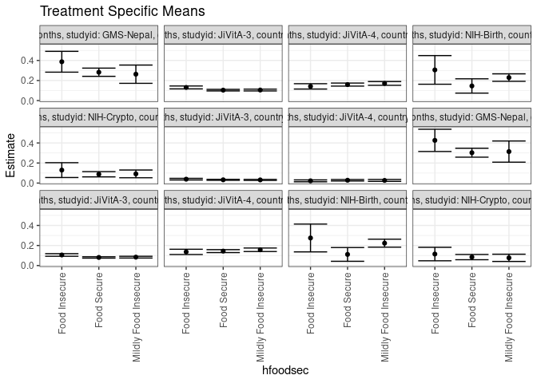

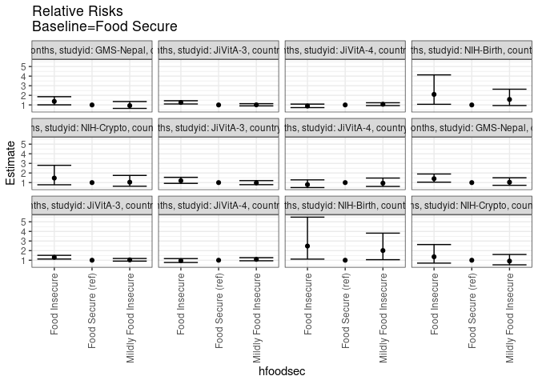

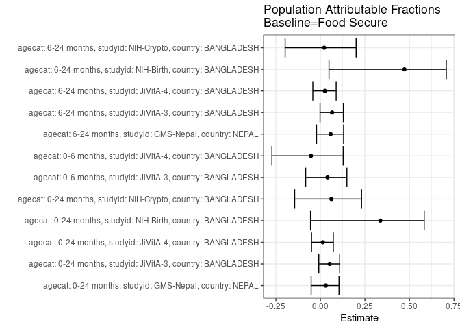

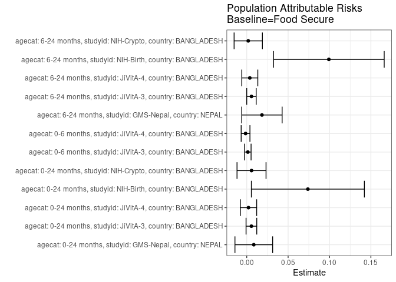

## Results Table

### Parameter: TSM

| agecat | studyid | country | intervention_level | baseline_level | estimate | ci_lower | ci_upper |
| --- | --- | --- | --- | --- | --- | --- | --- |
| 0-24 months | GMS-Nepal | NEPAL | Food Secure | NA | 0.2825735 | 0.2416267 | 0.3235203 |
| 0-24 months | GMS-Nepal | NEPAL | Mildly Food Insecure | NA | 0.2630553 | 0.1720388 | 0.3540718 |
| 0-24 months | GMS-Nepal | NEPAL | Food Insecure | NA | 0.3871723 | 0.2832981 | 0.4910465 |
| 0-24 months | JiVitA-3 | BANGLADESH | Food Secure | NA | 0.1040156 | 0.0962582 | 0.1117730 |
| 0-24 months | JiVitA-3 | BANGLADESH | Mildly Food Insecure | NA | 0.1050738 | 0.0959268 | 0.1142207 |
| 0-24 months | JiVitA-3 | BANGLADESH | Food Insecure | NA | 0.1309678 | 0.1164437 | 0.1454918 |
| 0-24 months | JiVitA-4 | BANGLADESH | Food Secure | NA | 0.1594172 | 0.1443604 | 0.1744740 |
| 0-24 months | JiVitA-4 | BANGLADESH | Mildly Food Insecure | NA | 0.1709692 | 0.1522701 | 0.1896684 |
| 0-24 months | JiVitA-4 | BANGLADESH | Food Insecure | NA | 0.1414804 | 0.1149273 | 0.1680336 |
| 0-24 months | NIH-Birth | BANGLADESH | Food Secure | NA | 0.1456747 | 0.0742182 | 0.2171312 |
| 0-24 months | NIH-Birth | BANGLADESH | Mildly Food Insecure | NA | 0.2293425 | 0.1920072 | 0.2666777 |
| 0-24 months | NIH-Birth | BANGLADESH | Food Insecure | NA | 0.3057592 | 0.1630152 | 0.4485032 |
| 0-24 months | NIH-Crypto | BANGLADESH | Food Secure | NA | 0.0878753 | 0.0616980 | 0.1140526 |
| 0-24 months | NIH-Crypto | BANGLADESH | Mildly Food Insecure | NA | 0.0915228 | 0.0528372 | 0.1302084 |
| 0-24 months | NIH-Crypto | BANGLADESH | Food Insecure | NA | 0.1292751 | 0.0554215 | 0.2031286 |
| 0-6 months | JiVitA-3 | BANGLADESH | Food Secure | NA | 0.0324302 | 0.0277066 | 0.0371538 |
| 0-6 months | JiVitA-3 | BANGLADESH | Mildly Food Insecure | NA | 0.0315368 | 0.0264130 | 0.0366605 |
| 0-6 months | JiVitA-3 | BANGLADESH | Food Insecure | NA | 0.0387025 | 0.0306009 | 0.0468041 |
| 0-6 months | JiVitA-4 | BANGLADESH | Food Secure | NA | 0.0281287 | 0.0207100 | 0.0355473 |
| 0-6 months | JiVitA-4 | BANGLADESH | Mildly Food Insecure | NA | 0.0264260 | 0.0168152 | 0.0360368 |
| 0-6 months | JiVitA-4 | BANGLADESH | Food Insecure | NA | 0.0222075 | 0.0130102 | 0.0314047 |
| 6-24 months | GMS-Nepal | NEPAL | Food Secure | NA | 0.3027335 | 0.2583958 | 0.3470711 |
| 6-24 months | GMS-Nepal | NEPAL | Mildly Food Insecure | NA | 0.3138691 | 0.2083171 | 0.4194211 |
| 6-24 months | GMS-Nepal | NEPAL | Food Insecure | NA | 0.4258464 | 0.3149891 | 0.5367038 |
| 6-24 months | JiVitA-3 | BANGLADESH | Food Secure | NA | 0.0809611 | 0.0741361 | 0.0877860 |
| 6-24 months | JiVitA-3 | BANGLADESH | Mildly Food Insecure | NA | 0.0838776 | 0.0749977 | 0.0927576 |
| 6-24 months | JiVitA-3 | BANGLADESH | Food Insecure | NA | 0.1054779 | 0.0925951 | 0.1183607 |
| 6-24 months | JiVitA-4 | BANGLADESH | Food Secure | NA | 0.1441027 | 0.1295577 | 0.1586477 |
| 6-24 months | JiVitA-4 | BANGLADESH | Mildly Food Insecure | NA | 0.1572492 | 0.1397063 | 0.1747921 |
| 6-24 months | JiVitA-4 | BANGLADESH | Food Insecure | NA | 0.1364463 | 0.1101453 | 0.1627474 |
| 6-24 months | NIH-Birth | BANGLADESH | Food Secure | NA | 0.1111111 | 0.0426082 | 0.1796140 |
| 6-24 months | NIH-Birth | BANGLADESH | Mildly Food Insecure | NA | 0.2232779 | 0.1834613 | 0.2630945 |
| 6-24 months | NIH-Birth | BANGLADESH | Food Insecure | NA | 0.2750000 | 0.1364985 | 0.4135015 |
| 6-24 months | NIH-Crypto | BANGLADESH | Food Secure | NA | 0.0844642 | 0.0583013 | 0.1106270 |
| 6-24 months | NIH-Crypto | BANGLADESH | Mildly Food Insecure | NA | 0.0770043 | 0.0408603 | 0.1131483 |
| 6-24 months | NIH-Crypto | BANGLADESH | Food Insecure | NA | 0.1147360 | 0.0474967 | 0.1819753 |

### Parameter: E(Y)

| agecat | studyid | country | intervention_level | baseline_level | estimate | ci_lower | ci_upper |
| --- | --- | --- | --- | --- | --- | --- | --- |
| 0-24 months | GMS-Nepal | NEPAL | NA | NA | 0.2911011 | 0.2564965 | 0.3257056 |
| 0-24 months | JiVitA-3 | BANGLADESH | NA | NA | 0.1096522 | 0.1044077 | 0.1148966 |
| 0-24 months | JiVitA-4 | BANGLADESH | NA | NA | 0.1615413 | 0.1501758 | 0.1729068 |
| 0-24 months | NIH-Birth | BANGLADESH | NA | NA | 0.2195513 | 0.1870467 | 0.2520558 |
| 0-24 months | NIH-Crypto | BANGLADESH | NA | NA | 0.0936675 | 0.0729118 | 0.1144233 |
| 0-6 months | JiVitA-3 | BANGLADESH | NA | NA | 0.0337775 | 0.0308809 | 0.0366741 |
| 0-6 months | JiVitA-4 | BANGLADESH | NA | NA | 0.0267062 | 0.0213205 | 0.0320920 |
| 6-24 months | GMS-Nepal | NEPAL | NA | NA | 0.3211169 | 0.2828539 | 0.3593799 |
| 6-24 months | JiVitA-3 | BANGLADESH | NA | NA | 0.0866585 | 0.0819882 | 0.0913288 |
| 6-24 months | JiVitA-4 | BANGLADESH | NA | NA | 0.1478180 | 0.1371861 | 0.1584499 |
| 6-24 months | NIH-Birth | BANGLADESH | NA | NA | 0.2103321 | 0.1759902 | 0.2446740 |
| 6-24 months | NIH-Crypto | BANGLADESH | NA | NA | 0.0863014 | 0.0659171 | 0.1066856 |

### Parameter: RR

| agecat | studyid | country | intervention_level | baseline_level | estimate | ci_lower | ci_upper |
| --- | --- | --- | --- | --- | --- | --- | --- |
| 0-24 months | GMS-Nepal | NEPAL | Food Secure | Food Secure | 1.0000000 | 1.0000000 | 1.000000 |
| 0-24 months | GMS-Nepal | NEPAL | Mildly Food Insecure | Food Secure | 0.9309271 | 0.6399576 | 1.354192 |
| 0-24 months | GMS-Nepal | NEPAL | Food Insecure | Food Secure | 1.3701650 | 1.0100863 | 1.858606 |
| 0-24 months | JiVitA-3 | BANGLADESH | Food Secure | Food Secure | 1.0000000 | 1.0000000 | 1.000000 |
| 0-24 months | JiVitA-3 | BANGLADESH | Mildly Food Insecure | Food Secure | 1.0101736 | 0.9019414 | 1.131393 |
| 0-24 months | JiVitA-3 | BANGLADESH | Food Insecure | Food Secure | 1.2591171 | 1.1022785 | 1.438272 |
| 0-24 months | JiVitA-4 | BANGLADESH | Food Secure | Food Secure | 1.0000000 | 1.0000000 | 1.000000 |
| 0-24 months | JiVitA-4 | BANGLADESH | Mildly Food Insecure | Food Secure | 1.0724638 | 0.9346962 | 1.230538 |
| 0-24 months | JiVitA-4 | BANGLADESH | Food Insecure | Food Secure | 0.8874853 | 0.7238803 | 1.088067 |
| 0-24 months | NIH-Birth | BANGLADESH | Food Secure | Food Secure | 1.0000000 | 1.0000000 | 1.000000 |
| 0-24 months | NIH-Birth | BANGLADESH | Mildly Food Insecure | Food Secure | 1.5743467 | 0.9389105 | 2.639834 |
| 0-24 months | NIH-Birth | BANGLADESH | Food Insecure | Food Secure | 2.0989179 | 1.0665433 | 4.130593 |
| 0-24 months | NIH-Crypto | BANGLADESH | Food Secure | Food Secure | 1.0000000 | 1.0000000 | 1.000000 |
| 0-24 months | NIH-Crypto | BANGLADESH | Mildly Food Insecure | Food Secure | 1.0415077 | 0.6212189 | 1.746145 |
| 0-24 months | NIH-Crypto | BANGLADESH | Food Insecure | Food Secure | 1.4711194 | 0.7726599 | 2.800963 |
| 0-6 months | JiVitA-3 | BANGLADESH | Food Secure | Food Secure | 1.0000000 | 1.0000000 | 1.000000 |
| 0-6 months | JiVitA-3 | BANGLADESH | Mildly Food Insecure | Food Secure | 0.9724509 | 0.7839900 | 1.206215 |
| 0-6 months | JiVitA-3 | BANGLADESH | Food Insecure | Food Secure | 1.1934087 | 0.9205147 | 1.547204 |
| 0-6 months | JiVitA-4 | BANGLADESH | Food Secure | Food Secure | 1.0000000 | 1.0000000 | 1.000000 |
| 0-6 months | JiVitA-4 | BANGLADESH | Mildly Food Insecure | Food Secure | 0.9394692 | 0.5995582 | 1.472088 |
| 0-6 months | JiVitA-4 | BANGLADESH | Food Insecure | Food Secure | 0.7894953 | 0.4857041 | 1.283297 |
| 6-24 months | GMS-Nepal | NEPAL | Food Secure | Food Secure | 1.0000000 | 1.0000000 | 1.000000 |
| 6-24 months | GMS-Nepal | NEPAL | Mildly Food Insecure | Food Secure | 1.0367836 | 0.7184332 | 1.496201 |
| 6-24 months | GMS-Nepal | NEPAL | Food Insecure | Food Secure | 1.4066712 | 1.0437917 | 1.895708 |
| 6-24 months | JiVitA-3 | BANGLADESH | Food Secure | Food Secure | 1.0000000 | 1.0000000 | 1.000000 |
| 6-24 months | JiVitA-3 | BANGLADESH | Mildly Food Insecure | Food Secure | 1.0360244 | 0.9066077 | 1.183915 |
| 6-24 months | JiVitA-3 | BANGLADESH | Food Insecure | Food Secure | 1.3028227 | 1.1242603 | 1.509745 |
| 6-24 months | JiVitA-4 | BANGLADESH | Food Secure | Food Secure | 1.0000000 | 1.0000000 | 1.000000 |
| 6-24 months | JiVitA-4 | BANGLADESH | Mildly Food Insecure | Food Secure | 1.0912296 | 0.9426798 | 1.263188 |
| 6-24 months | JiVitA-4 | BANGLADESH | Food Insecure | Food Secure | 0.9468686 | 0.7653151 | 1.171492 |
| 6-24 months | NIH-Birth | BANGLADESH | Food Secure | Food Secure | 1.0000000 | 1.0000000 | 1.000000 |
| 6-24 months | NIH-Birth | BANGLADESH | Mildly Food Insecure | Food Secure | 2.0095012 | 1.0576908 | 3.817841 |
| 6-24 months | NIH-Birth | BANGLADESH | Food Insecure | Food Secure | 2.4750000 | 1.1164457 | 5.486720 |
| 6-24 months | NIH-Crypto | BANGLADESH | Food Secure | Food Secure | 1.0000000 | 1.0000000 | 1.000000 |
| 6-24 months | NIH-Crypto | BANGLADESH | Mildly Food Insecure | Food Secure | 0.9116803 | 0.5196704 | 1.599400 |
| 6-24 months | NIH-Crypto | BANGLADESH | Food Insecure | Food Secure | 1.3583985 | 0.7007247 | 2.633340 |

### Parameter: PAR

| agecat | studyid | country | intervention_level | baseline_level | estimate | ci_lower | ci_upper |
| --- | --- | --- | --- | --- | --- | --- | --- |
| 0-24 months | GMS-Nepal | NEPAL | Food Secure | NA | 0.0085276 | -0.0142359 | 0.0312910 |
| 0-24 months | JiVitA-3 | BANGLADESH | Food Secure | NA | 0.0056366 | -0.0008266 | 0.0120998 |
| 0-24 months | JiVitA-4 | BANGLADESH | Food Secure | NA | 0.0021241 | -0.0077519 | 0.0120001 |
| 0-24 months | NIH-Birth | BANGLADESH | Food Secure | NA | 0.0738766 | 0.0056177 | 0.1421355 |
| 0-24 months | NIH-Crypto | BANGLADESH | Food Secure | NA | 0.0057922 | -0.0117341 | 0.0233186 |
| 0-6 months | JiVitA-3 | BANGLADESH | Food Secure | NA | 0.0013473 | -0.0025577 | 0.0052524 |
| 0-6 months | JiVitA-4 | BANGLADESH | Food Secure | NA | -0.0014224 | -0.0067180 | 0.0038731 |
| 6-24 months | GMS-Nepal | NEPAL | Food Secure | NA | 0.0183835 | -0.0059872 | 0.0427541 |
| 6-24 months | JiVitA-3 | BANGLADESH | Food Secure | NA | 0.0056975 | -0.0000119 | 0.0114069 |
| 6-24 months | JiVitA-4 | BANGLADESH | Food Secure | NA | 0.0037153 | -0.0059546 | 0.0133852 |
| 6-24 months | NIH-Birth | BANGLADESH | Food Secure | NA | 0.0992210 | 0.0323673 | 0.1660747 |
| 6-24 months | NIH-Crypto | BANGLADESH | Food Secure | NA | 0.0018372 | -0.0152564 | 0.0189308 |

### Parameter: PAF

| agecat | studyid | country | intervention_level | baseline_level | estimate | ci_lower | ci_upper |
| --- | --- | --- | --- | --- | --- | --- | --- |
| 0-24 months | GMS-Nepal | NEPAL | Food Secure | NA | 0.0292942 | -0.0521303 | 0.1044171 |
| 0-24 months | JiVitA-3 | BANGLADESH | Food Secure | NA | 0.0514044 | -0.0091107 | 0.1082904 |
| 0-24 months | JiVitA-4 | BANGLADESH | Food Secure | NA | 0.0131488 | -0.0499281 | 0.0724362 |
| 0-24 months | NIH-Birth | BANGLADESH | Food Secure | NA | 0.3364890 | -0.0555253 | 0.5829121 |
| 0-24 months | NIH-Crypto | BANGLADESH | Food Secure | NA | 0.0618383 | -0.1446381 | 0.2310693 |
| 0-6 months | JiVitA-3 | BANGLADESH | Food Secure | NA | 0.0398881 | -0.0828014 | 0.1486760 |
| 0-6 months | JiVitA-4 | BANGLADESH | Food Secure | NA | -0.0532624 | -0.2722530 | 0.1280338 |
| 6-24 months | GMS-Nepal | NEPAL | Food Secure | NA | 0.0572485 | -0.0217502 | 0.1301393 |
| 6-24 months | JiVitA-3 | BANGLADESH | Food Secure | NA | 0.0657463 | -0.0020590 | 0.1289634 |
| 6-24 months | JiVitA-4 | BANGLADESH | Food Secure | NA | 0.0251343 | -0.0426021 | 0.0884699 |
| 6-24 months | NIH-Birth | BANGLADESH | Food Secure | NA | 0.4717349 | 0.0481092 | 0.7068319 |
| 6-24 months | NIH-Crypto | BANGLADESH | Food Secure | NA | 0.0212880 | -0.1981193 | 0.2005161 |